# Loan Exploration by Nikos Tavoularis

# Multivariate Plots Section

As we said before it is interesting to see if loan takers before the financial crisis of 2008 had different behaviour than those after 2008. The dataset contains 29.051 loans for the period 2005-2008 and 26.033 for the period 2009-2014. So the data split is almost even (53% - 47%).

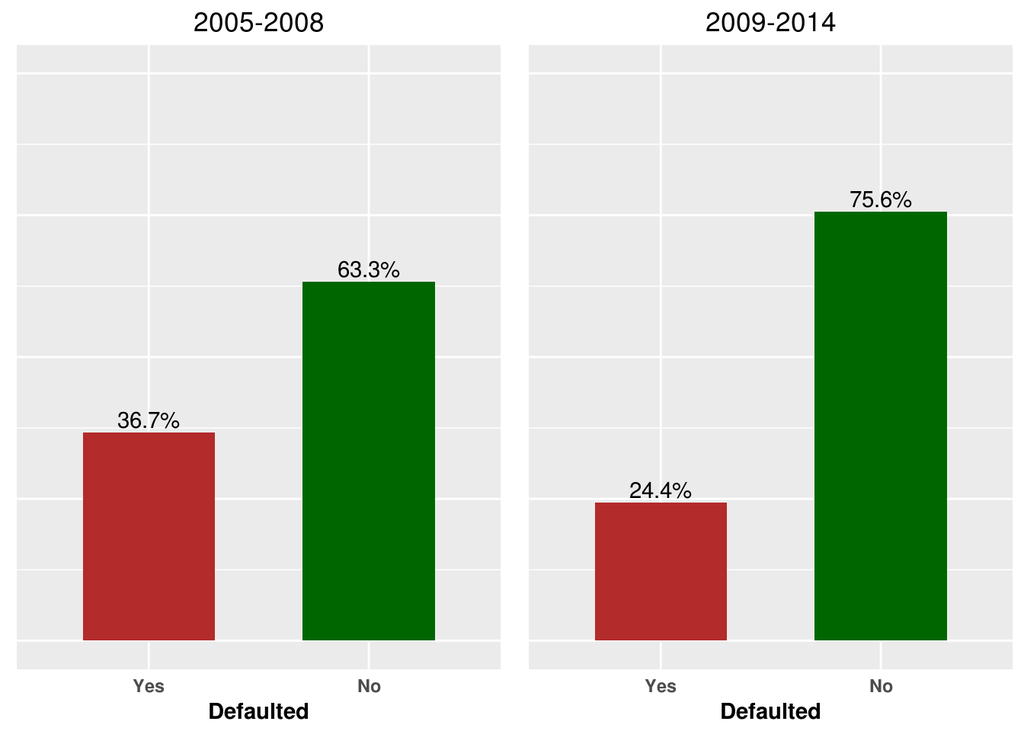

More that 1/3 loans in 2005-2008 defaulted in the PROSPER platform. PROSPER managed to decrease the default ratio below 1/4 in 2009-2014.

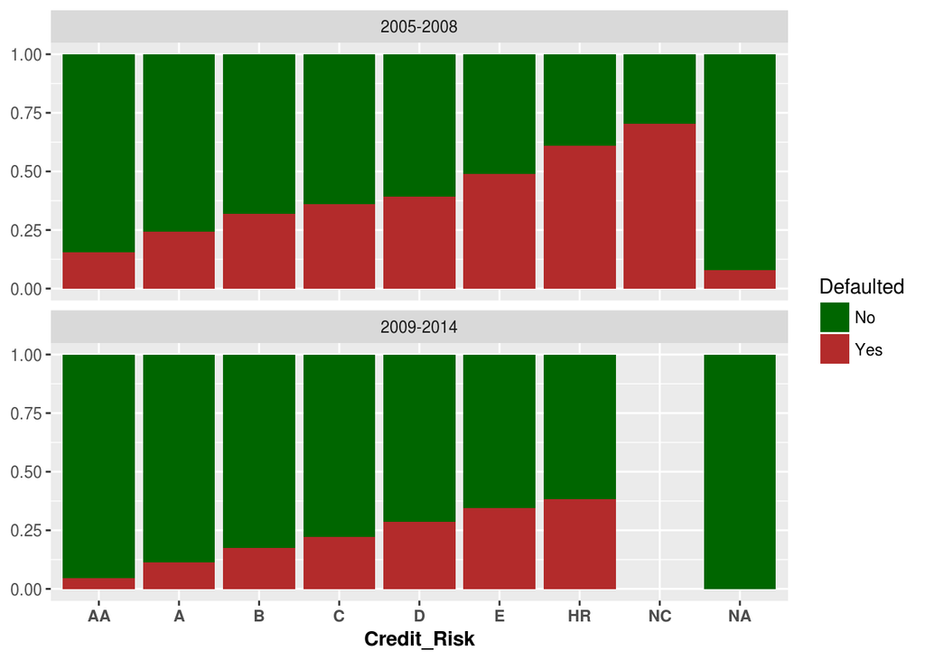

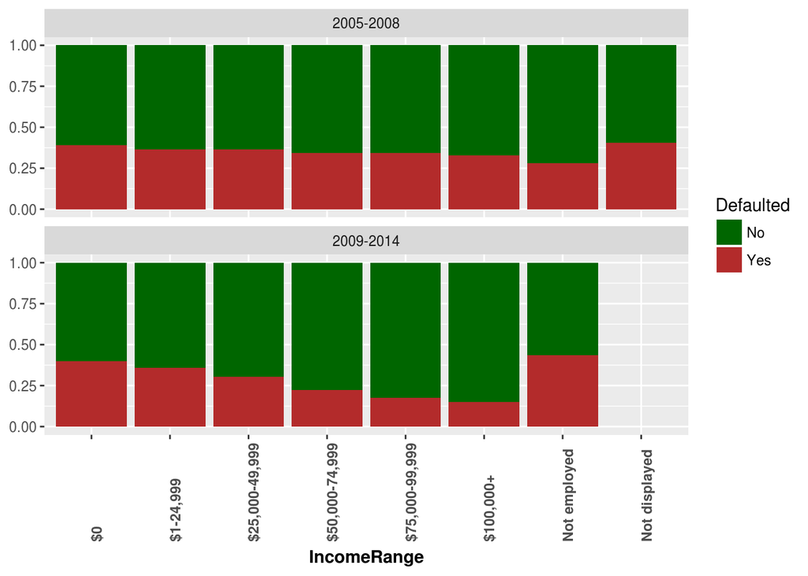

The above graph reveals that income range was negatively correlated with the default rate for loans after 2009. For loans before the financial crisis the correlation is present but it is much smaller.

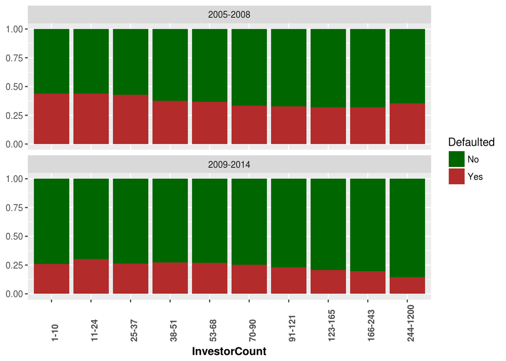

The same pattern as with the income range is spotted to a lesser extent with the number of investors. More than 68 investors per loan signifies a lower rate of default for the second period. This relation holds true for all categories in the first period up until 244 investors.

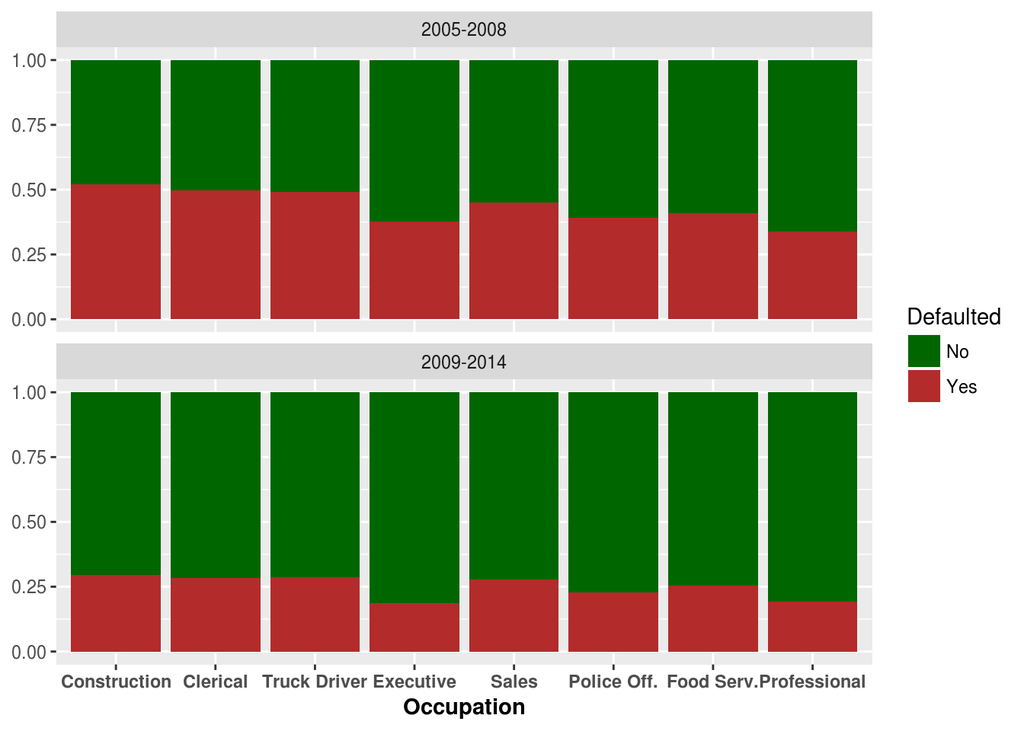

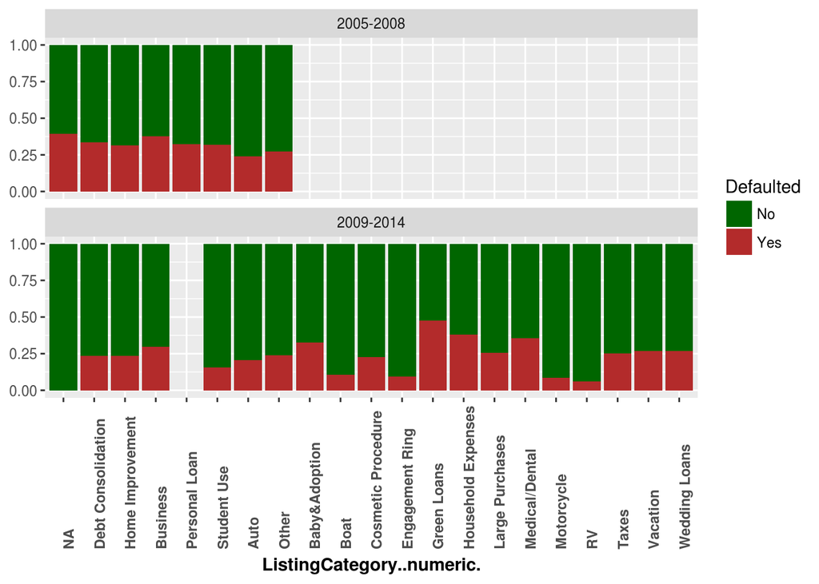

In the above graph we can notice that PROSPER added several loan categories after 2009, but excluded the personal loan category from its listings.

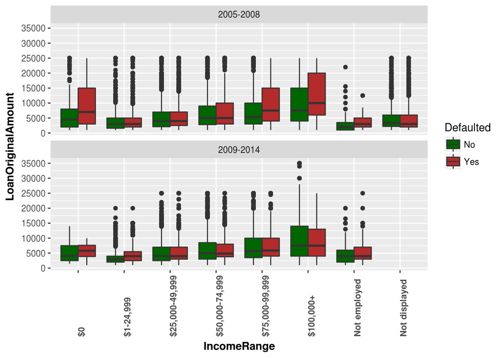

The above graph reveals that defaulted loans in period 2005-2008 had a larger range of listing amounts in most income categories. This pattern isn’t visible in the period 2009-2014.

### Talk about some of the relationships you observed in this part of the investigation. Were there features that strengthened each other in terms of looking at your feature(s) of interest?

Splitting the data in two time periods revealed some interesting relationships between the examined variables. The rate of default was substantially lower in 2009-2014 compared to 2005-2008. Default rates were lower across all credit risk categories compared to the period 2005-2008 and income range of loan takers seemed to infuence a lot more the deafult rate after 2009. Also we discovered that PROSPER added new listing categories after 2009.

### Were there any interesting or surprising interactions between features?

When plotting loan amount vs income range for both periods it was somewhat unexpected that defaulted loans in the first period had a larger range of listing amounts in most income categories. We will try to explain this observation in the next section.

# Final Plots and Summary

### Plot One

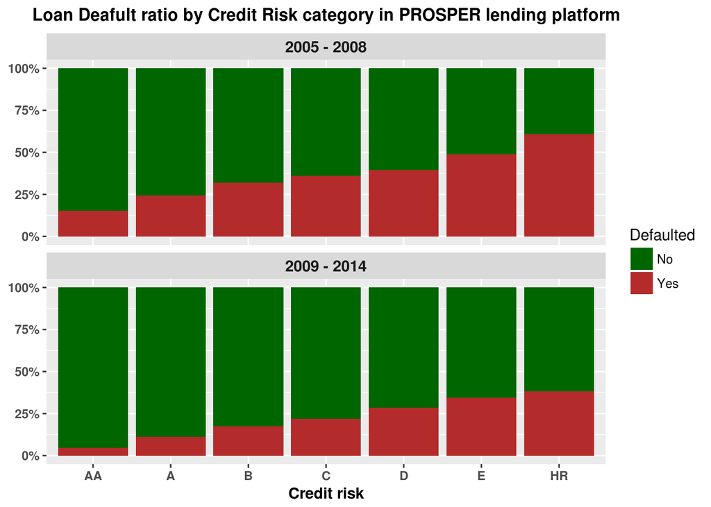

### Description One

I believe the above graph is self-explanatory. It shows that PROSPER made its credit risk system stricter from 2009 and onwards. Despite the abysmal performance of loan takers in 2005-2008, the graph shows that PROSPER managed to correctly seperate loan takers into different credit risk categories in 2005-2008 because the default rate exhibits a ladder pattern as in 2009-2014. But the main problem in the period 2005-2008 is that PROSPER failed to exclude certain loan takers from taking a loan in the first place. It is not reasonable to allow people taking a loan if their probability of default is close or above 50% (i.e. categories E and HR in 2005-2008). This is of course an ex post info but given the fact that the first period covers 3 years I believe there was enough time for PROSPER to adjust its credit risk policy. To PROSPER defence we can say that when a company starts operations it is inevidable that some things may go south. We shouldn’t also forget that there is always a need for new customers for newly established companies. Furthermore the [financial crisis](https://en.wikipedia.org/wiki/Financial_crisis_of_2007%E2%80%932008) that hit the world economy in 2007-2008 certainly played it’s role to the far than stellar performance of loan takers in 2005-2008.

Plz note that in the above graph we dropped the NC (No Credit) and NA (Not Available) credit risk categories for better representing the data (they contain only 272 observations, 0.5% of all observations).

### Plot Two

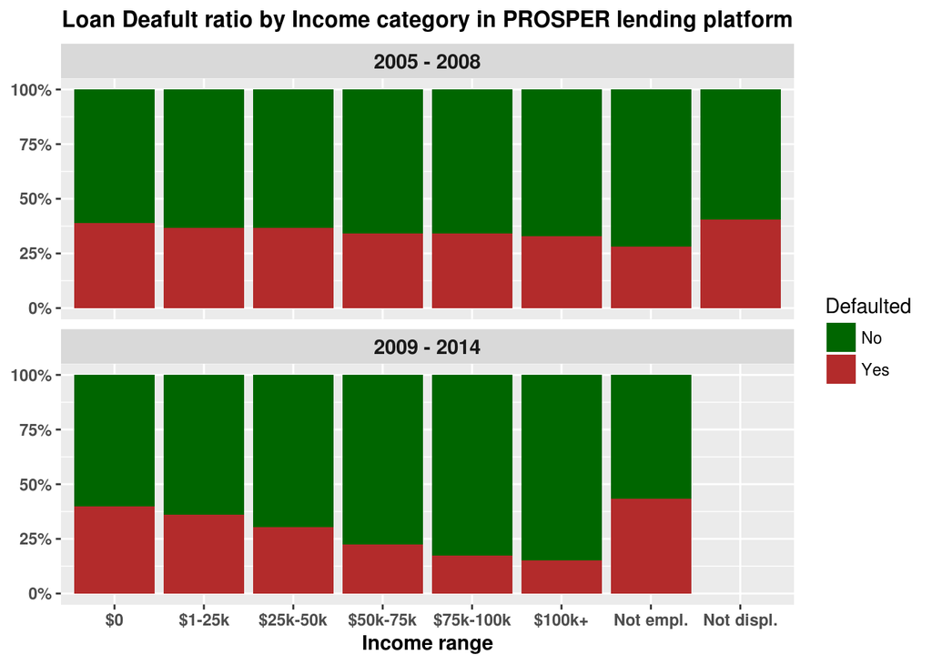

### Description Two

Several things can be noticed in the above graph. First of all it seems that after 2009 there was no option for a loan taker to not display his/her income. Probably this happened because during the period 2005-2008 this income range category had the highest rate of default. Secondly the default ratio is highly correlated with income range in 2009-20014. This is not the case in 2005-2008 where the drop in default rate as income range increases not so visually strong. We can make two hypothesis for this observation: either the effect of the financial crisis hit all income categories to the same extent (which I think is highly unlikely) or PROSPER didn’t have a mechanism to verify the stated income of loan takers and loan takers took advantage of it. I think this last hypothesis is further supported by the fact that the “Not employed” category had the smallest default rate in 2005-2008 (which doesn’t make sense), but in 2009-2014 it had the largest one.

### Plot Three

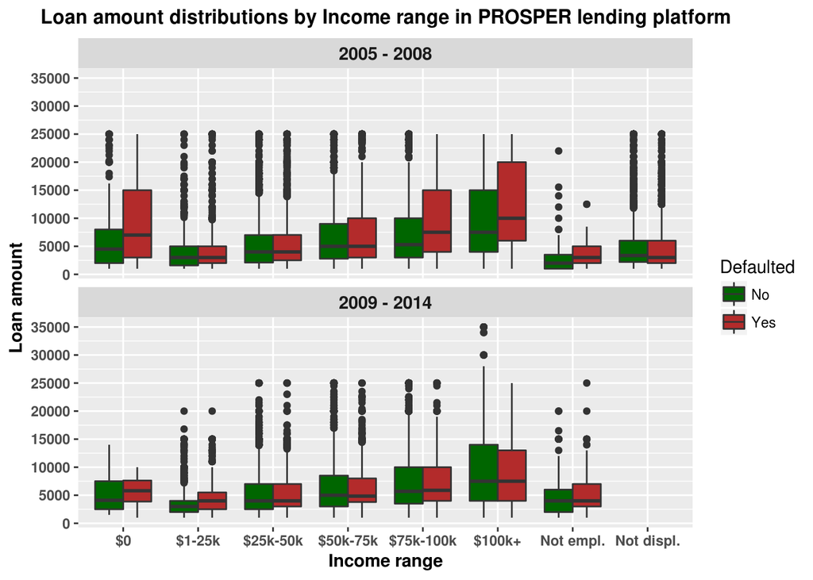

### Description Three

In the last plot we can easily spot a trend: as income range grows so does the loan amount. But the $0 category seems to brake this trend because it’s distribution of loan amounts lies above the income category $1-25k category. As it was analysed during the bivariate plots section the $0 income loans are few, they are mainly concentrated in 2007 and 2008 and they are probably loans on behalf of small companies, so we can ignore them in this graph.

Another issue that is visible is that the distribution of defaulted loans during 2005-2008 is more spread out than non defaulted loans across several income categories. This isn’t something to be expected. In general every bank that lends money takes heavily into consideration the income of each loan taker before giving a loan. This isn’t inline with what is seen in the graph of 2005-2008. We should note that this tendancy was evaporated in the period 2009-2014.

A final observation about the above graph is that as income range increase loan range amount increseases also.

# Reflection

Exploring the PROSPER loan dataset was really interesting. I discovered many insights about the peer-to-peer lending which I wasn’t aware of. In fact this type of lending in Europe is not at all common. The main difficulties that I encountered during this project were related to the variable selection that I did. I wanted to explore the categorical variables of this dataset mainly because I haven’t been exposed to this type of data analysis in the past and learning to do so would be useful.

The most common pattern throught out this dataset exploration is that PROSPER had a difficult time during the first years of it’s operation and a part of it can be attributed to the financial crisis that unfolded after 2008. Nevertheless, it seems that their credit rating system wasn’t at all optimal because more than 1/3 of their loans defaulted during 2005-2008. So it is not strange that the SEC imposed a cease and desist order on PROSPER from the end of November 2008 till July 2009. Moving after the SEC order PROSPER managed to fix its credit rating system and the default rates were normalised to fairly acceptable rates.

To this end adding a model that forecasts which loans will default on the PROSPER platform is certainly feasible. We could use the variables that were explored in this project and seemed to be related with the default ratio. This is something that I will definetely try to do in the future.